# Analysis of Spatial Networks From Bipartite Projections Using the R `backbone` Package

Neal, Z. P., Domagalski, R., & Sagan, B. (2022).  
*Geographical Analysis*, 54, 623–647

곽지호

지리학과 석사과정

2026년 9월 29일

## 저자 소개

[Zachary P. Neal](https://www.zacharyneal.com/)

- Michigan State University 심리학과 교수
- [GaWC(Globalization & World Cities)](https://www.lboro.ac.uk/gawc/) 연구 그룹의 일원
- 네트워크 기반 지리학, 사회학, 교육학, 심리학 연구
- R 패키지 `backbone` 개발자 및 유지보수자 [CRAN](https://cran.r-project.org/package=backbone)

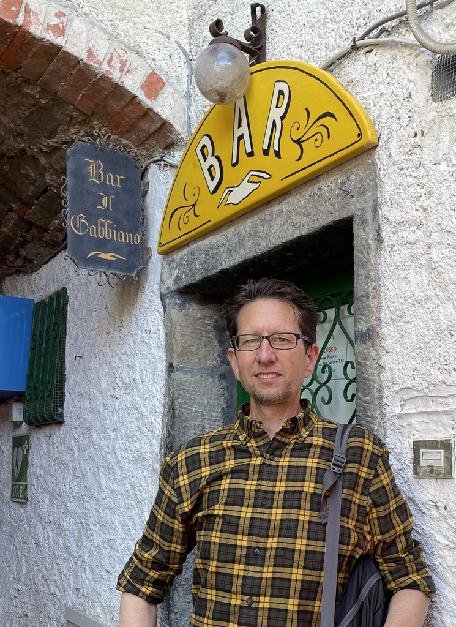

## 논문 소개

**4단계 구성**

1. 이론적 배경
2. `backbone` 패키지 소개
3. `backbone` 패키지를 활용한 세계 도시 네트워크 분석 사례
4. 공간 네트워크 분석에서 이분 투영 활용 시의 주의점

# 이론적 배경

## 이분 네트워크

[figure not shown]

- 네트워크: 노드(node)와 엣지(edge)로 구성
- 네트워크 $\Leftrightarrow$ 정방 행렬 (square matrix)
  - 노드 $\Leftrightarrow$ 행과 열
  - 엣지 $\Leftrightarrow$ 원소
- 이분 네트워크 (bipartite network): 두 종류의 노드로 구성된 네트워크
  - 행위자 (agents)와 아티팩트 (artifacts)
  - 엣지는 행위자 $\longleftrightarrow$ 아티팩트 만을 연결

## 이분 투영

[figure not shown]

- 이분 네트워크는 직사각형 행렬($\mathbf{B}$)로 표현
  - 행: 행위자(agents)
  - 열: 아티팩트(artifacts)
  - 행위자 $i$가 아티팩트 $j$와 연결되어 있으면 $B_{ij} = 1$, 그렇지 않으면 0
- 이분 네트워크를 투영하면 단일 네트워크(unipartite network)로 표현 가능
  - 투영 = $\mathbf{B}$와 $\mathbf{B}$의 전치행렬을 곱함 ($\mathbf{P} = \mathbf{B}\mathbf{B}'$) $\rightarrow$ 대칭 정방 행렬
  - 이분 투영의 원소 $P_{ij}$
    - ($i\neq j$) 행위자 $i$와 $j$가 공유하는 아티팩트 수 (비대각성분)
    - ($i = j$) 행위자 $i$가 속한 아티팩트 수 (대각성분)

## 행렬 기초

- 인덱싱 (R: `A[i, j]`)
  - 아랫첨자를 이용하여 행렬의 원소 표기
  - 순서대로 (행, 열) e.g. $A_{12}$ = 1번째 행 2번째 열의 원소
- 행렬 곱 (R: `A %*% B`)
  - (m x n) * (n x p) = (m x p)
  - $(\mathbf{A}\mathbf{B})_{ij} = \sum_k A_{ik} B_{kj}$

$$\underbrace{\begin{pmatrix} \bbox[#d5ecd4,3pt]{1} & \bbox[#d5ecd4,3pt]{0} \\ 1 & 1 \\ 0 & 1 \end{pmatrix}}_{3 \times 2}
\underbrace{\begin{pmatrix} \bbox[#e4dcf4,3pt]{1} & 1 & 0 \\ \bbox[#e4dcf4,3pt]{0} & 1 & 1 \end{pmatrix}}_{2 \times 3}
=
\underbrace{\begin{pmatrix} 1 & 1 & 0 \\ 1 & 2 & 1 \\ 0 & 1 & 1 \end{pmatrix}}_{3 \times 3}$$

- 전치 행렬 (transpose) (R: `t(M)`)
  - 행과 열의 위치를 바꾸는 것
  - $(\mathbf{M}')_{ij} = M_{ji}$

$$\mathbf{M} = \begin{pmatrix} 1 & 0 \\ 1 & 1 \\ 0 & 1 \end{pmatrix}
\;\Rightarrow\;
\mathbf{M}' = \begin{pmatrix} 1 & 1 & 0 \\ 0 & 1 & 1 \end{pmatrix}$$

## 이분 네트워크 예시

[figure not shown]

**이분 네트워크: 행위자 5개 도시 x 아티팩트 4개 기업**

- 이분 행렬 $\mathbf{B}$: 5 × 4
  - 행 = 행위자(도시), 열 = 아티팩트(기업)
  - $B_{ik} = 1$: 행위자 $i$가 아티팩트 $k$에 연결
- 행합 = 행위자가 연결된 아티팩트 수
  - e.g. 런던에는 4개의 기업 위치
- 열합 = 아티팩트에 연결된 행위자 수
  - e.g. KPMG와 Barclays는 3개 도시에 위치

## 이분 투영 예시

[figure not shown]

이분 네트워크 예시로

**이분 투영 $\mathbf{P} = \mathbf{B}\mathbf{B}'$: 두 행위자가 공유하는 아티팩트**

- $\mathbf{P}$: (5 × 4)(4 × 5) = 5 × 5
- $P_{3,5}$: $\mathbf{B}$의 3행 · $\mathbf{B}'$의 5열 ($\Leftrightarrow$ $\mathbf{B}$의 5행)
  $$\begin{pmatrix} \bbox[#d5ecd4,3pt]{1} & \bbox[#d5ecd4,3pt]{1} & \bbox[#d5ecd4,3pt]{1} & \bbox[#d5ecd4,3pt]{1} \end{pmatrix}
  \begin{pmatrix} \bbox[#e4dcf4,3pt]{0} \\ \bbox[#e4dcf4,3pt]{0} \\ \bbox[#e4dcf4,3pt]{1} \\ \bbox[#e4dcf4,3pt]{1} \end{pmatrix}
  = 0 + 0 + 1 + 1 = \bbox[#ffe680,3pt]{2}$$
- 런던과 시드니는 2개의 기업 공유 → 엣지 가중치 2
- 대각원소 $P_{ii}$ = 행합 (e.g. $P_{CC} = 4$)

## 공간적 이분 네트워크

- 위치를 행위자로 한 접근
  - 여러 가지 공간 스케일에서 다양한 활용
  - 세계 도시 네트워크 (Taylor 2001)
    - 도시 - 행위자 / 기업 - 아티팩트
    - 근거: 같은 기업의 지사 간에는 상호작용 존재
- 위치를 아티팩트로 한 접근
  - 개인 또는 사회적 주체들의 네트워크
  - 가구 단위 소셜 네트워크 (Browning et al 2017 등)
    - 가구 - 행위자 / 통근, 통학 장소 - 아티팩트
    - 근거: 같은 장소에 있으면 사회적으로 연결될 확률 높음

## 이분 투영의 장점 및 주의점

- 장점
  - 데이터 수집 용이
    - 도시 간 경제 네트워크 측정
    - 시민들 간 사회적 네트워크 측정
- 주의점
  - 뒷받침하는 이론이 중요
    - 모든 이진 직사각형 행렬을 투영($\mathbf{P} = \mathbf{B}\mathbf{B}'$)할 수 있지만, 그것이 꼭 ’네트워크’임을 함의하지 않음
    - 아티팩트의 공유를 ’연결’로 해석할 수 있는 이유 뒷받침 필요
    - e.g. 국기 색깔을 공유하면 연결?

## 이분 투영의 방법론적 어려움

- 이분 투영은 가중 네트워크: 비가중 네트워크보다 가중 네트워크 분석이 더 어려움
- 더해서, 이분 네트워크의 투영에서 엣지의 가중치는 강한 연결을 함의하지 않음
- 대표적 분석 방법: 임계값(threshold) 기준 이진(비가중) 행렬로 변환 후 분석 -> 한계
  1. 중심성이 작은 노드들이 과소평가됨
  2. 구조가 없는 임의의 이분 행렬도 높은 정도로 군집됨
  3. 일부 네트워크 구조(open triad, stars)는 관측 불가능

## 이분 투영의 뼈대(backbones)

- 가중 네트워크인 이분 투영에서 뼈대를 추출해내는 작업 필요
- “통계적으로 유의하게” 중요한 엣지만 남기기
  - 두 행위자 간 엣지의 가중치가 랜덤으로 네트워크가 만들어졌을 때보다 강한가?
  - ’랜덤’의 정의에 따라 여러 모델 존재
- 기존의 가중 네트워크 뼈대 추출 모델을 적용할 수 없음 -> `backbone` 패키지의 개발

## 뼈대 추출 절차 및 필요성

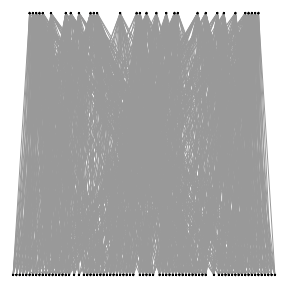

이분 네트워크 ($\mathbf{B}$)

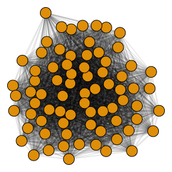

이분 투영 ($\mathbf{P}$)

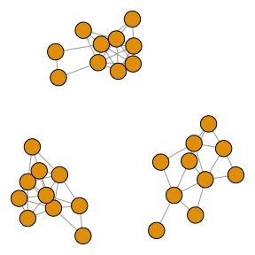

뼈대 (backbones)

# `backbone` 패키지

## `backbone` 패키지 소개

- R 패키지로 개발 (Domagalski et al. 2021; Neal 2022; Neal 2026)
- CRAN(R 오픈 소스 패키지 공식 저장소)에서 설치 가능

```r
library(backbone)
```

- 패키지 설명서

```r
?backbone
vignette("backbone")
```

- Caveat: 현재는 버전 3.0.4로 함수 문법들이 다수 변경됨 (논문: 버전 1.2.2)

## 세 가지 유형의 함수

1. 전통적 가중 이분 투영 (weighted bipartite projection)

```r
universal()
```

2. 통계적 유의성 검정을 위한 확률분포 유도

```r
hyperg(); sdsm(); fdsm()
```

3. 통계적으로 유의한 엣지만으로 네트워크 구성

```r
backbone.extract()
```

# `backbone`을 이용한 세계 도시 네트워크 분석 - (1) 이분 투영 만들기

## 데이터 - GaWC Data Set 11

[figure not shown]

- 2000년에 수집 (최신: 2020년)
- 315개 도시 x 100개 고차생산자서비스 기업
- 도시별 기업 사무소의 규모에 따라 0~5점 부여
- 아래 출처에서 도시/기업/코드 부여 방식 확인 가능
- 출처: [GaWC Data](https://gawc.lboro.ac.uk/gawc-worlds/gawc-data/dataset-11/) | [Replication Code](https://osf.io/r2evn/)

## 이분 네트워크 구축

$$B'_{ij} =
\begin{cases}
1 & \text{if } B_{ij} \ge 3 \\
0 & \text{if } B_{ij} \le 2
\end{cases}$$

```r
# 원본: https://gawc.lboro.ac.uk/wp-content/uploads/2024/08/da11.csv
B <- read.csv(file="data/da11.csv", header = TRUE, row.names = 1)
B <- as.matrix(B)

B[B <= 2] <- 0  # 0, 1, 2 (보통 이하 규모의 사무소)는 0으로
B[B >= 3] <- 1  # 3, 4, 5 (보통보다 큰 사무소)는 1로
B <- B[rowSums(B) != 0,]  # 전부 0인 행 (사무소가 없는 도시) 제거
```

## EDA

```r
B[114:117, 8:11]
```

```
            Horwath KPMG Summit...Baker RSM
MELBOURNE         0    1              0   1
MEXICO CITY       0    1              0   0
MIAMI             1    1              0   1
MILAN             0    0              0   1
```

```r
rowSums(B)["AMSTERDAM"]  # 암스테르담에 있는 기업 수
```

```
AMSTERDAM
       29
```

```r
rowSums(B)["NEW YORK"]  # 뉴욕에 있는 기업 수
```

```
NEW YORK
      74
```

```r
colSums(B)["KPMG"]  # KPMG가 있는 도시 수
```

```
KPMG
  76
```

```r
colSums(B)["HSBC"]  # HSBC가 있는 도시 수
```

```
HSBC
  43
```

## EDA

- (a) 도시 별 입지 기업 수 분포 | (b) 기업 별 입지 도시 수 분포

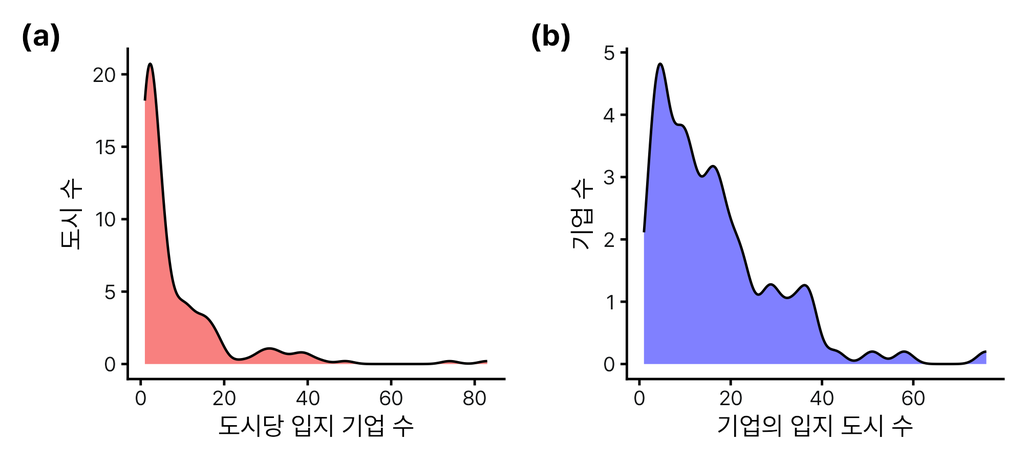

## 가중 이분 투영

- 가중 이분 투영 실행 $\mathbf{P} = \mathbf{B}\mathbf{B}'$ -> 도시 간 네트워크로

```r
P <- B %*% t(B)
```

- 대표 조합: 암스테르담 - 뉴욕

```r
P["AMSTERDAM","NEW YORK"]  # 암스테르담과 뉴욕에 모두 있는 기업 수
```

```
[1] 26
```

## 기존 분석(global network centrality, GNC)의 한계

- 기존 분석: GNC(도시에 연결된 엣지 가중치 총합)

```r
sort(rowSums(P), decreasing = TRUE)[1:5]  # 연결 정도(degree) 상위 5개 도시 (GNC)
```

```
   LONDON  NEW YORK     PARIS HONG KONG SINGAPORE
     1496      1403      1043      1032       913
```

```r
cor(rowSums(P), rowSums(B))  # 상관계수: 연결 정도와 기업 수
```

```
[1] 0.9767704
```

- 중심 도시 = 기업 수가 많은 도시
  - 네트워크 분석이 필요한 결론은 아님

# `backbone`을 이용한 세계 도시 네트워크 분석 - (2) 뼈대 추정하기

## 1. 전역 임계값 (universal threshold)

- 0 초과
- 25 초과
- 평균 + 2표준편차 초과

```r
universal0 <- universal(B, upper = 0, bipartite = TRUE)
table(universal0$backbone)
```

```
    0     1
21506 16910
```

```r
mean(universal0$backbone)  # 밀도
```

```
[1] 0.4401812
```

```r
sort(rowSums(universal0$backbone), decreasing = TRUE)[1:5]  # 연결 정도 상위 5개 도시
```

```
     LONDON    NEW YORK       PARIS   HONG KONG LOS ANGELES
        191         185         175         171         171
```

```r
cor(rowSums(universal0$backbone), rowSums(B))  # 상관계수: 연결 정도와 기업 수
```

```
[1] 0.7407175
```

- 공유 기업이 하나라도 있으면 연결
- 조밀한(dense) 뼈대 (44% 유지)
- 여전히 규모가 큰 도시가 상위 중심지로 보고됨 ($r=0.74$)

```r
universal25 <- universal(B, upper = 25,
                            bipartite = TRUE)
mean(universal25$backbone)  # 밀도
```

```
[1] 0.001665973
```

```r
sort(rowSums(universal25$backbone), decreasing = TRUE)[1:5]  # 연결 정도 상위 5개 도시
```

```
   LONDON  NEW YORK HONG KONG     PARIS   CHICAGO
       15        12         5         5         3
```

```r
cor(rowSums(universal25$backbone), rowSums(B))  # 상관계수: 연결 정도와 기업 수
```

```
[1] 0.8381523
```

```r
universal.meansd <- universal(B, upper = function(x)mean(x)+2*sd(x),
                                 bipartite = TRUE)
mean(universal.meansd$backbone)  # 밀도
```

```
[1] 0.03092461
```

```r
sort(rowSums(universal.meansd$backbone), decreasing = TRUE)[1:5]  # 연결 정도 상위 5개 도시
```

```
   LONDON  NEW YORK HONG KONG     PARIS SINGAPORE
       64        61        51        49        42
```

```r
cor(rowSums(universal.meansd$backbone), rowSums(B))  # 상관계수: 연결 정도와 기업 수
```

```
[1] 0.9655334
```

- 평균 + 2$\sigma$ 이상인 연결만 유지
- 밀도: 3%; 여전히 기업 수가 많은 도시를 채택함

## 전역 임계값 방법의 한계

- 도시별 기업 수를 통제하지 않음
- 기업 수가 많은 도시가 높은 연결성을 지닌 것으로 채택됨
- 기업 수의 분산이 클 때 EDA -> 통제 필요

## 무엇을 통제한 ’랜덤’인가?

- “우연이라면 나올 수 있는” 가상의 $\mathbf{B}$ 행렬 집합을 구성
- p-value: 이 집합에서 $\mathbf{B}^*$를 하나 뽑았을 때 $P^*_{AB}$가 관측값 이상일 확률 -> 유의성 검정

$$\mathbf{B} = \begin{array}{c|cccc|c}
& 1 & 2 & 3 & 4 & \text{행합} \\ \hline
A & 1&0&0&0 & 1 \\
B & 1&0&0&0 & 1 \\
C & 1&1&1&1 & 4 \\
D & 0&0&1&0 & 1 \\
E & 0&0&1&1 & 2 \\ \hline
\text{열합} & 3 & 1 & 3 & 2 &
\end{array}$$

- **HM**: 행합만 고정
  - 가능한 행렬 4×4×1×4×6 = 384개
- **FDSM**: 행합과 열합을 모두 정확히 고정
  - 가능한 행렬은 12개
- **SDSM**: 행합과 열합이 **평균적으로** 맞도록
  - 5×4 이진행렬 2<sup>20</sup> = 1,048,576개 전부 후보
  - 합이 정확히 맞지 않는 행렬도 포함

## 기대 공유 계산: HM

Fig. 1의 $\mathbf{B}$와 $\mathbf{P} = \mathbf{B}\mathbf{B}'$ (관측값 $P_{AB} = 1$)

$$\mathbf{B} = \begin{array}{c|cccc|c}
& 1 & 2 & 3 & 4 & \text{행합} \\ \hline
A & ? & ? & \cdots & ? & \bbox[#f5d0dc,2pt]{1} \\
B & ? & ? & \cdots & ? & \bbox[#f5d0dc,2pt]{1} \\
C & \vdots & \vdots & \ddots & \vdots & \bbox[#f5d0dc,2pt]{4} \\
D & & & & & \bbox[#f5d0dc,2pt]{1} \\
E & ? & ? & \cdots & ? & \bbox[#f5d0dc,2pt]{2} \\ \hline
\text{열합} & ? & ? & \cdots & ? &
\end{array}$$
$$\mathbf{P} = \begin{array}{c|ccccc}s
& A & B & C & D & E \\ \hline
A & ? & \bbox[#ffe680,2pt]{1} & ? & \cdots & ? \\
B & \bbox[#ffe680,2pt]{1} & ? & ? & \cdots & ? \\
C & \vdots & \vdots & \vdots & \ddots & \vdots \\
D & & & & & \\
E & ? & ? & ? & \cdots & ?
\end{array}$$

### 행합만 고정

**A와 B가 4개 중 1개를 독립적으로 고름**

공유 수 $X \sim \text{H}(N = 4,\ K = r_A,\ n = r_B)$

$$E[X] = \frac{r_A \, r_B}{N} = \frac{1 \times 1}{4} = 0.25$$

$$p = P(X \ge 1) = 1 - \frac{\binom{3}{1}}{\binom{4}{1}} = \frac{1}{4} = 0.25$$

- 의미: 도시별 기업 수가 지금과 같을 때, A, B 도시가 1개 기업 (관측값) 이상을 공유할 확률은 0.25

## 기대 공유 계산: FDSM

Fig. 1의 $\mathbf{B}$와 $\mathbf{P} = \mathbf{B}\mathbf{B}'$ (관측값 $P_{AB} = 1$)

$$\mathbf{B} = \begin{array}{c|cccc|c}
& 1 & 2 & 3 & 4 & \text{행합} \\ \hline
A & ? & ? & \cdots & ? & \bbox[#f5d0dc,2pt]{1} \\
B & ? & ? & \cdots & ? & \bbox[#f5d0dc,2pt]{1} \\
C & \vdots & \vdots & \ddots & \vdots & \bbox[#f5d0dc,2pt]{4} \\
D & & & & & \bbox[#f5d0dc,2pt]{1} \\
E & ? & ? & \cdots & ? & \bbox[#f5d0dc,2pt]{2} \\ \hline
\text{열합} & \bbox[#d0e4f5,2pt]{3} & \bbox[#d0e4f5,2pt]{1} & \bbox[#d0e4f5,2pt]{3} & \bbox[#d0e4f5,2pt]{2} &
\end{array}$$
$$\mathbf{P} = \begin{array}{c|ccccc}
& A & B & C & D & E \\ \hline
A & ? & \bbox[#ffe680,2pt]{1} & ? & \cdots & ? \\
B & \bbox[#ffe680,2pt]{1} & ? & ? & \cdots & ? \\
C & \vdots & \vdots & \vdots & \ddots & \vdots \\
D & & & & & \\
E & ? & ? & ? & \cdots & ?
\end{array}$$

### 행합과 열합을 모두 고정

**C는 행합 4 -> 모든 기업에 고정됨**  
남은 열합 (3, 1, 3, 2) − 1 = (2, 0, 2, 1)

| E의 선택 | 남은 열합 | 경우의 수 | A–B 공유 |
| --- | --- | --- | --- |
| {1, 3} | (1, 1, 1) | 3! = 6 | 0 |
| {1, 4} | (1, 2, 0) | 3 | 1 |
| {3, 4} | (2, 1, 0) | 3 | 1 |
| 합계 |  | 12 | 2 |

$$E[X] = p = P(X \ge 1) = \frac{2}{12} \approx .17$$

- 의미: 도시별 기업 수와 기업별 입지 도시 수가 지금과 같을 때, A, B 도시가 1개 기업 (관측값) 이상을 공유할 확률은 0.17

## 모형별 귀무 분포 및 뼈대 추출

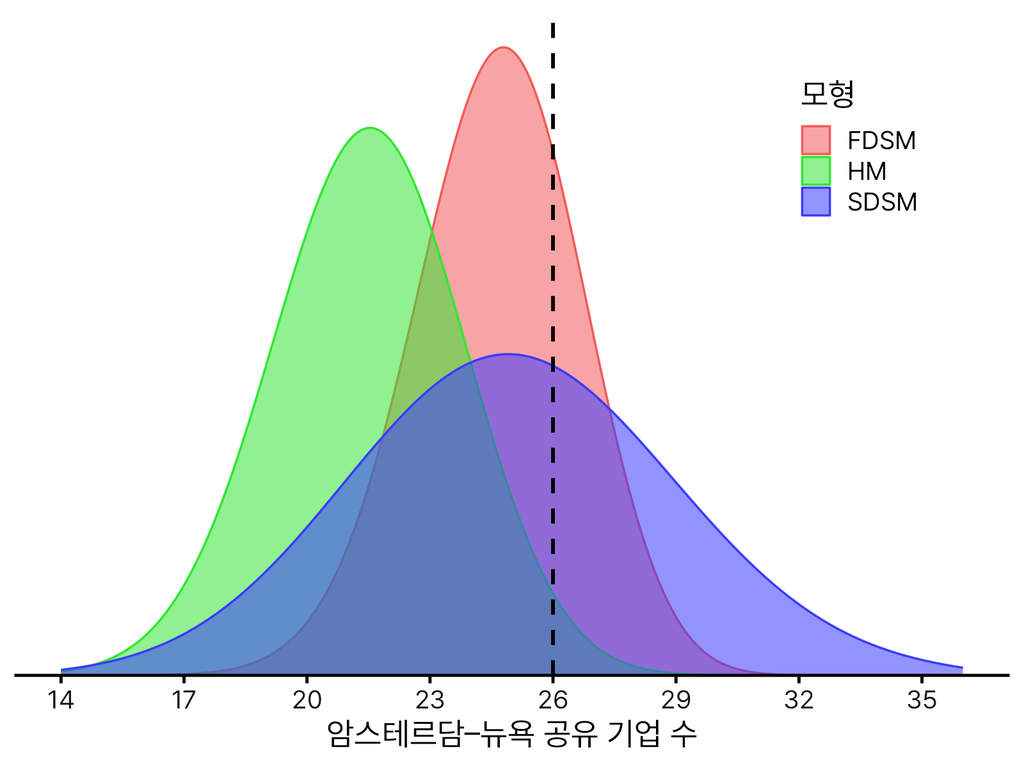

**같은 관측값도 귀무모형에 따라 유의성이 달라짐**

- 검은 점선: 관측값 (암스테르담–뉴욕 26개 기업 공유)
- 뼈대 추출: 관측값이 위쪽 기각역에 들면 엣지로 남김
- 의미: “두 도시가 의미 있는 경제적 상호작용을 한다고 결론 내릴 만큼” 공유 기업이 많은 쌍만 이은 네트워크
- 중심지: “경제적 상호작용 네트워크”에서 중심인 도시
- 결과 지도: [backbone_map](https://jihography.github.io/backbone_map/)

## 2. 초기하분포 모형 (hypergeometric model, HM)

- 도시별 기업 수(행합) 통제
- 암스테르담–뉴욕 공유 기업 수의 귀무분포 (α = 0.1, 양측검정 중 위쪽 꼬리만 사용)

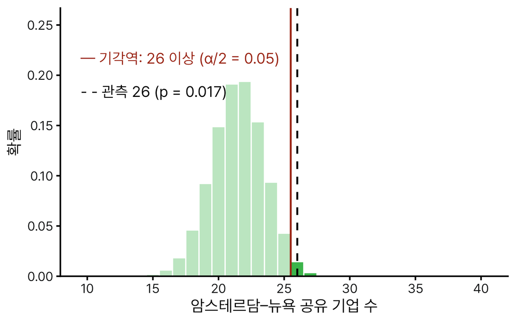

## 2. 초기하분포 모형: 코드

```r
hyper <- hyperg(B)
# hyper$summary
hyperbb <- backbone.extract(hyper, alpha = 0.1, signed = FALSE)
mean(hyperbb)  # 밀도
```

```
[1] 0.09225323
```

```r
sort(rowSums(hyperbb), decreasing = TRUE)[1:5]  # 연결 정도 상위 5개 도시
```

```
INDIANAPOLIS     PORTLAND    MELBOURNE         LYON     AUCKLAND
          60           54           52           49           44
```

```r
cor(rowSums(hyperbb), rowSums(B))  # 상관계수: 연결 정도와 기업 수
```

```
[1] 0.3039028
```

## 3. 고정 차수 수열 모형 (fixed degree sequence model, FDSM)

- 도시별 기업 수(행합)와 기업별 입지 도시 수(열합)를 정확히 통제
- 암스테르담–뉴욕 공유 기업 수의 귀무분포 (α = 0.1, 양측검정 중 위쪽 꼬리만 사용)

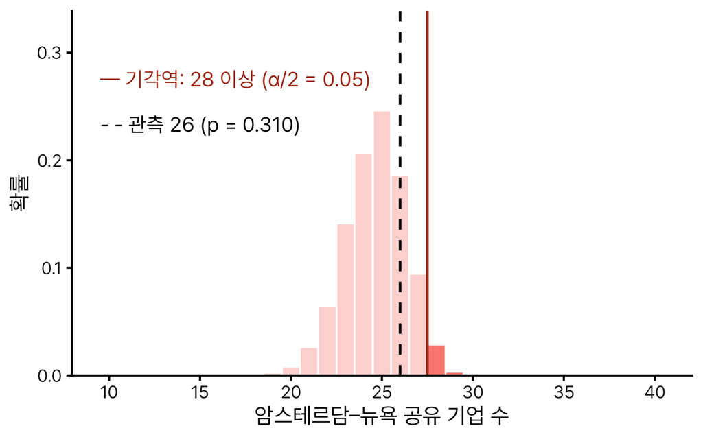

## 3. 고정 차수 수열 모형: 코드

```r
set.seed(5)
fdsm <- fdsm(B, trials = 10000, progress = TRUE)
# fdsm$summary
fdsmbb <- backbone.extract(fdsm, alpha = 0.1, signed = FALSE)
mean(fdsmbb)  # 밀도
```

```
[1] 0.02202207
```

```r
sort(rowSums(fdsmbb), decreasing = TRUE)[1:5]  # 연결 정도 상위 5개 도시
```

```
 KANSAS CITY    CHARLOTTE     RICHMOND INDIANAPOLIS     BORDEAUX
          24           21           21           20           17
```

```r
cor(rowSums(fdsmbb), rowSums(B))  # 상관계수: 연결 정도와 기업 수
```

```
[1] -0.002749457
```

## 4. 확률적 차수 수열 모형 (stochastic degree sequence model, SDSM)

- 도시별 기업 수(행합)와 기업별 입지 도시 수(열합)를 평균적으로 통제
- 암스테르담–뉴욕 공유 기업 수의 귀무분포 (α = 0.2, 양측검정 중 위쪽 꼬리만 사용)

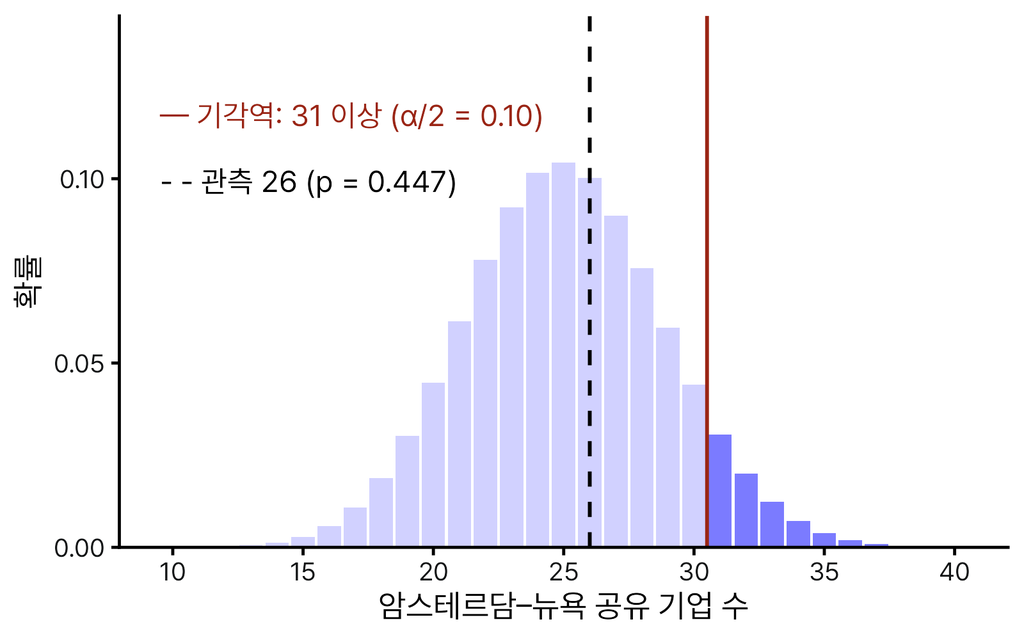

## 4. 확률적 차수 수열 모형: 코드

```r
sdsm <- sdsm(B)
# sdsm$summary
sdsmbb <- backbone.extract(sdsm, alpha = 0.2, signed = FALSE, narrative = TRUE)
mean(sdsmbb)  # 밀도
```

```
[1] 0.01973136
```

```r
sort(rowSums(sdsmbb), decreasing = TRUE)[1:5]  # 연결 정도 상위 5개 도시
```

```
 KANSAS CITY    CHARLOTTE     RICHMOND INDIANAPOLIS     BORDEAUX
          24           21           20           18           17
```

```r
cor(rowSums(sdsmbb), rowSums(B))  # 상관계수: 연결 정도와 기업 수
```

```
[1] -0.1062661
```

```r
cor(as.vector(fdsmbb),as.vector(sdsmbb))  # 상관계수: FDSM 뼈대와 SDSM 뼈대
```

```
[1] 0.9301515
```

# 논의

## 공간 네트워크 분석에서 이분 투영 활용 시의 주의점

- 네트워크 구축은 **이론**에 근거해야 함
  - 아티팩트 공유가 왜, 어떤 상호작용을 뜻하는지 명시
- 뼈대 추출 모형의 선택 기준 (논문 Fig. 4)
  - 전역 임계값: 행합과 열합 모두 차이가 없을 때
  - HM: 행합만 차이가 있고 열합은 고를 때
  - FDSM: 행합과 열합 모두 차이가 있을 때 (대부분의 실제 자료)
  - SDSM: FDSM과 같은 조건에서 자료가 클 때 (속도 개선)

## 한계점

- 뼈대 추출 모형의 타당성 검증 부족
  - 독립적으로 측정한 ‘실제(true)’ 공간 네트워크와 비교 필요
  - e.g. 항공 교통 (Taylor et al. 2007), 은행 네트워크 (Pažitka et al. 2021)
- 이진 행렬과 행렬 곱 투영만 다룸
  - GaWC 원자료의 사무소 규모(0–5점)를 버림
  - 조건부 확률, measures of interestingness 기반 투영에는 적용 불가
- 소프트웨어 측면
  - 투영이 아닌 가중 네트워크(e.g. 교통량)에는 적용 불가
  - 모형 선택은 사용자 몫 (자동화 필요)

## 논평 및 질문 (1)

**1. 이론의 타당성: 통계적 유의성이 해결해주지 않는 것**

- 검정은 “규모에 비해 많이 공유함”만 보여줌 -> “공유=상호작용”이라는 가정(이론)은 별개
  - Pažitka et al. (2021): 기업 입지 기반(OLA) 세계 도시 네트워크 비판
- OLA 데이터 구성의 의문점
  - 국내 도시 간 연결(e.g. 캔자스 시티)도 세계 도시 간 상호작용으로 볼 수 있는가?
  - 기업의 국가별 사무소 수를 통제해야 할 필요 있지 않은가? (e.g. 삼성 -> 베이징 / 텐진)

## 논평 및 질문 (2)

**2. 이진화 임계값에 대한 민감도 분석**

- $\mathbf{P}$의 임의 임계값은 비판하면서 $\mathbf{B}$는 “3 이상”으로 임의 이진화
- 기준을 2 혹은 4 이상으로 바꾸면 뼈대와 상위 도시가 얼마나 달라지는가?

**3. 규모를 통제한 결과의 해석**

- FDSM, SDSM 뼈대의 중심 도시는 중간 규모 지역 중심지 (e.g. 캔자스 시티)
- 런던, 뉴욕 같은 최상위 도시는 상위권에서 사라짐: “세계 경제 상호작용의 중심지”라는 직관과 어긋남
- 제한적 해석: “중요한 연결”이 아니라 “규모로 설명되지 않는 연결”이 아닐지?